# STAT 331 Portfolio

Author

Nick Carboni

**My Grade:** I believe my grade equivalent to course work evidenced below to be an A-.

**Learning Objective Evidence:** In the code chunks below, provide code from Lab or Challenge assignments where you believe you have demonstrated proficiency with the specified learning target. Be sure to specify **where** the code came from (e.g., Lab 4 Question 2).

## Working with Data

**WD-1: I can import data from a *variety* of formats (e.g., csv, xlsx, txt, etc.).**

- `csv` Example 1

```r
# Lab 2, Q1 - Revised
surveys <- read_csv(here('week-1', 'surveys.csv'))
```

- `csv` Example 2

```r
# Lab 3, Q2
teacher_evals <- read_csv(here('week-3','teacher_evals.csv'))
```

- `xlsx`

```r
# PA 4 - Revised
military <- read_xlsx(here("gov_spending_per_capita.xlsx"),
                      sheet = "Share of Govt. spending",
                      skip  = 7,
                      n_max = 190,
                      na = c("..", ". .", "xxx")
                      )
```

**WD-2: I can select necessary columns from a dataset.**

- Example selecting specified columns

```r
# Lab 3, Q5
teacher_evals_clean <- teacher_evals |>
  rename(sex = gender) |>
  filter(no_participants >= 10) |>
  mutate(teacher_id = as.character(teacher_id),
         academic_degree = as.factor(academic_degree),
         sex = as.factor(sex)) |>
  select(course_id,
         teacher_id,
         question_no,
         no_participants,
         resp_share,
         SET_score_avg,
         percent_failed_cur,
         academic_degree,
         seniority,
         sex)
```

- Example removing specified columns

```r
# Lab 3, Q5 - Revised
teacher_evals_clean <- teacher_evals |>
  rename(sex = gender) |>
  filter(no_participants >= 10) |>
  mutate(teacher_id = as.character(teacher_id),
         academic_degree = as.factor(academic_degree),
         sex = as.factor(sex)) |>
  select(-c(stud_grade_avg,
            stud_grade_std,
            stud_grade_var_coef,
            stud_grade_avg_cur,
            stud_grade_std_cur,
            stud_grade_var_coef_cur,
            class_duration,
            weekday,
            time_of_day,
            SET_score_1sem,
            maximum_score))
```

- Example selecting columns based on logical values (e.g., `starts_with()`, `ends_with()`, `contains()`, `where()`)

```r
# Lab 4, Q7 - Revised
ca_childcare |>
  mutate(census_region = fct_relevel(census_region, regions)) |>
  filter(census_region %in% regions) |>
  select(study_year,
         census_region,
         contains("mc_")) |>
  pivot_longer(cols = contains("mc_"),
               names_to = "age_cohort",
               values_to = "median_price") |>
  mutate(age_cohort = fct_recode(age_cohort,
                                 "Infant" = "mc_infant",
                                 "Toddler" = "mc_toddler",
                                 "Preschool" = "mc_preschool"))
```

**WD-3: I can filter rows from a dataframe for a *variety* of data types (e.g., numeric, integer, character, factor, date).**

- Numeric Example 1

```r
# Lab 3, Q5
teacher_evals_clean <- teacher_evals |>
  rename(sex = gender) |>
  filter(no_participants >= 10) |>
  mutate(teacher_id = as.character(teacher_id),
         academic_degree = as.factor(academic_degree),
         sex = as.factor(sex)) |>
  select(course_id,
         teacher_id,
         question_no,
         no_participants,
         resp_share,
         SET_score_avg,
         percent_failed_cur,
         academic_degree,
         seniority,
         sex)
```

- Numeric Example 2

```r
# Lab 3, Q9
teacher_evals_clean |>
  count(teacher_id,
        course_id) |>
  filter(n == 9) |>
  nrow()
```

- Character Example 1 (any context)

```r
# Lab 3, Q12
teacher_evals_clean |>
  filter(academic_degree %in% c("dr", "ma")) |>
  group_by(teacher_id,
           seniority,
           sex) |>
  summarize(response_avg = mean(resp_share),
            .groups = "drop") |>
  filter(response_avg == max(response_avg) |
         response_avg == min(response_avg)) |>
  arrange(response_avg) |>
  kable()
```

- Character Example 2 (example must use functions from **stringr**)

```r
# Lab 5, 'Looking for witness #2'
person |>
  filter(address_street_name == "Franklin Ave",
         str_detect(name,
                    pattern = "^Annabel")) |>
  rename('person_id' = 'id') |>
  left_join(interview) |>
  select(person_id,
         name,
         transcript) |>
  kable()
```

- Date (example must use functions from **lubridate**)

```r
# Lab 5, 'Crime Scene Report' - Revised
crime_scene_report |>
  mutate(date = ymd(date)) |>
  filter(date == ymd('2018-1-15'),
         type == 'murder') |>
  kable()
```

**WD-4: I can modify existing variables and create new variables in a dataframe for a *variety* of data types (e.g., numeric, integer, character, factor, date).**

- Numeric Example 1

```r
# Challenge 7, Q5
# Creating a new numeric column using a function
condition_index <- function(weight, length) {
  weight / (length * length * length) * 100
}

fish |>
  mutate(condition_index = condition_index(weight, length))
```

- Numeric Example 2

```r
# Lab 3, Q7 - Revised
teacher_evals_clean |>
  distinct(teacher_id, course_id, .keep_all = TRUE) |>
  count(sex) |>
  mutate(proportion = n / sum(n))
```

- Factor Example 1 (renaming levels)

```r
# Lab 4, Q7
# Using fct_recode to rename levels
regions <- c("San Francisco", "Orange", "Los Angeles", "Northern San Joaquin", "Southern San Joaquin", "Central Coast", "Inland Empire", "Superior", "San Diego-Imperial", "North Coast")

ca_childcare |>
  mutate(census_region = fct_relevel(census_region, regions)) |>
  filter(census_region %in% regions) |>
  select(study_year,
         census_region,
         mc_infant,
         mc_toddler,
         mc_preschool) |>
  pivot_longer(cols = c(mc_infant,
                        mc_toddler,
                        mc_preschool),
               names_to = "age_cohort",
               values_to = "median_price") |>
  mutate(age_cohort = fct_recode(age_cohort,
                                 "Infant" = "mc_infant",
                                 "Toddler" = "mc_toddler",
                                 "Preschool" = "mc_preschool"))
```

- Factor Example 2 (reordering levels)

```r
# Lab 4, Q7
# Using fct_relevel to reorder levels according to a given vector
ca_childcare |>
  mutate(census_region = fct_relevel(census_region, regions)) |>
  filter(census_region %in% regions) |>
  select(study_year,
         census_region,
         mc_infant,
         mc_toddler,
         mc_preschool) |>
  pivot_longer(cols = c(mc_infant,
                        mc_toddler,
                        mc_preschool),
               names_to = "age_cohort",
               values_to = "median_price") |>
  mutate(age_cohort = fct_recode(age_cohort,
                                 "Infant" = "mc_infant",
                                 "Toddler" = "mc_toddler",
                                 "Preschool" = "mc_preschool"))
```

- Character (example must use functions from **stringr**)

```r
# Lab 5, 'Looking for witness #2' - Revised
# Using str_c() to create a detailed testimony column
person |>
  filter(address_street_name == "Franklin Ave",
         str_detect(name,
                    pattern = "^Annabel")) |>
  rename('person_id' = 'id') |>
  left_join(interview) |>
  mutate(testimony = str_c('Testimony of ID #', person_id,
                           ' - ', name,
                           ': ', transcript)) |>
  select(testimony) |>
  kable()
```

- Date (example must use functions from **lubridate**)

```r
# Lab 5, 'Crime Scene Report' - Revised
# Using ymd() to create a date column
crime_scene_report |>
  mutate(date = ymd(date)) |>
  filter(date == ymd('2018-1-15'),
         type == 'murder') |>
  kable()
```

**WD-5: I can use mutating joins to combine multiple dataframes.**

- `left_join()` Example 1

```r
# Lab 4, Q2
ca_childcare <- childcare_costs|>
  left_join(counties, by = 'county_fips_code') |>
  filter(state_abbreviation == 'CA')
```

- `right_join()` Example 1

```r
# Lab 5, 'Looking for Witness' - Revised
person |>
  filter(address_street_name == "Franklin Ave",
         str_detect(name,
                    pattern = "^Annabel")) |>
  rename('person_id' = 'id') |>
  right_join(interview) |>
  filter(!is.na(name) ) |>
  select(person_id,
         name,
         transcript) |>
  kable()
```

- `left_join()` **or** `right_join()` Example 2

```r
# Lab 4, Q3
ca_childcare <- ca_childcare |>
  left_join(tax_rev, by = c("study_year" = "year",
                            "county_name" = "entity_name"))
```

- `inner_join()` Example 1

```r
# Lab 5, 'Investigating Witness #1' - Revised
person |>
  filter(address_street_name == "Northwestern Dr",
         address_number == max(address_number)) |>
  inner_join(interview,
            by = c('id' = 'person_id')) |>
  kable()
```

- `inner_join()` Example 2

```r
# Lab 5, 'Tracking down the suspect' - Revised
get_fit_now_member |>
  filter(str_detect(id,
                    pattern = "^48(z|Z)"),
         membership_status == 'gold') |>
  inner_join(person,
             by = c('person_id' = 'id', 'name' = 'name')) |>
  inner_join(drivers_license,
             by = c('license_id' = 'id')) |>
  filter(str_detect(plate_number,
                    pattern = 'H42W')) |>
  inner_join(interview,
             by = 'person_id') |>
  select(id,
         plate_number,
         membership_status,
         name,
         transcript) |>
  kable()
```

**WD-6: I can use filtering joins to filter rows from a dataframe.**

- `semi_join()`

```r
# Lab 5, 'More layers to this murder...' - Revised
# find possible suspects based off some criteria
suspect_criteria <- drivers_license |>
  filter(height %in% c(65,66,67),
         hair_color == 'red',
         car_make == 'Tesla')

# Filter 'person' to keep only those matching the criteria
person |>
  semi_join(suspect_criteria, by = c("license_id" = "id"))
```

- `anti_join()`

```r
# Lab 3, Q9
# find which teacher-course combos asked all 9 questions
asked_all <- teacher_evals_clean |>
  count(teacher_id, course_id) |>
  filter(n == 9)

# will return # of combos who DID ask all questions
asked_all |>
  nrow()

# will return # of combos of who DID NOT ask all questions
teacher_evals_clean |>
  anti_join(asked_all, by = c("teacher_id", "course_id")) |>
  nrow()

# 49 asked all questions
# 6376 failed to ask all the questions
```

**WD-7: I can pivot dataframes from long to wide and visa versa**

- `pivot_longer()`

```r
# Lab 4, Q7
ca_childcare |>
  mutate(census_region = fct_relevel(census_region, regions)) |>
  filter(census_region %in% regions) |>
  select(study_year,
         census_region,
         mc_infant,
         mc_toddler,
         mc_preschool) |>
  pivot_longer(cols = c(mc_infant,
                        mc_toddler,
                        mc_preschool),
               names_to = "age_cohort",
               values_to = "median_price") |>
  mutate(age_cohort = factor(age_cohort,
                             levels = c("mc_infant", "mc_toddler", "mc_preschool"),
                             labels = c("Infant", "Toddler", "Preschool")))
```

- `pivot_wider()`

```r
# Lab 4, Q5
ca_childcare_median_income_by_region_over_time <- ca_childcare |>
  group_by(census_region,
           study_year) |>
  summarize(median_income = median(mhi_2018, na.rm = TRUE)) |>
  pivot_wider(names_from = study_year,
              values_from = median_income,
              names_prefix = "year_") |>
  arrange(desc(year_2018)) |>
  select(c("census_region",
           "year_2008",
           "year_2018"))
```

## Reproducibility

**R-1: I can create professional looking, reproducible analyses using RStudio projects, Quarto documents, and the here package.**

I demonstrated this learning target in Lab 3, Lab/Challenge 4, and Lab 5, Lab 7, Lab 8, Lab/Challenge 9

**R-2: I can write well documented and tidy code.**

- Example of **ggplot2** plotting

```r
# Lab 2, Q16 - Revised
surveys |>
  ggplot(mapping = aes(y = species,
                     x = weight)) +
  geom_boxplot(outliers = FALSE) +
  geom_jitter(color = 'steelblue',
              alpha = .05) +
  labs(title = 'Weight Distribution of Various Species \nin Portal, AZ',
       x = 'Species Name',
       y = 'Weight (g)') +
  theme_bw()
```

- Example of **dplyr** pipeline

```r
# Lab 3, Q5
teacher_evals_clean <- teacher_evals |>
  rename(sex = gender) |>
  filter(no_participants >= 10) |>
  mutate(teacher_id = as.character(teacher_id),
         academic_degree = as.factor(academic_degree),
         sex = as.factor(sex)) |>
  select(course_id,
         teacher_id,
         question_no,
         no_participants,
         resp_share,
         SET_score_avg,
         percent_failed_cur,
         academic_degree,
         seniority,
         sex)
```

- Example of function formatting

```r
# Lab 7, Q4
# Min-Max Normalization Function
rescale_01 <- function(vec) {
  if(!is.numeric(vec)) {
    stop('Please provide a numeric vector.')
  }
  if(length(vec) <= 1){
    stop('Please provide a vector with more than one element')
  }
  # (x - min) / (max - min)
  vec_range <- range(vec, na.rm = TRUE)
  (vec - vec_range[1]) / (vec_range[2] - vec_range[1])
}
```

**R-3: I can write robust programs that are resistant to changes in inputs.**

- Example (any context)

```r
# Lab 4, Q7 - Revised
# This code would be reistant if for example, a new column prefixed with mc_ (Like mc_kindergarten) was added
ca_childcare |>
  mutate(census_region = fct_relevel(census_region, regions)) |>
  filter(census_region %in% regions) |>
  select(study_year,
         census_region,
         contains("mc_")) |>
  pivot_longer(cols = contains("mc_"),
               names_to = "age_cohort",
               values_to = "median_price")
```

- Example (function stops)

```r
# Lab 7, Q4
# Min-Max Normalization Function
rescale_01 <- function(vec) {
  if(!is.numeric(vec)) {
    stop('Please provide a numeric vector.')
  }
  if(length(vec) <= 1){
    stop('Please provide a vector with more than one element')
  }
  # (x - min) / (max - min)
  vec_range <- range(vec, na.rm = TRUE)
  (vec - vec_range[1]) / (vec_range[2] - vec_range[1])
}
```

## Data Visualization & Summarization

**DVS-1: I can create visualizations for a *variety* of variable types (e.g., numeric, character, factor, date)**

- At least two numeric variables

```r
# Challenge 4, 'Building a visualization'
# numeric: center based care median price
# numeric: family based care median price
childcare_long |>
  filter(study_year %in% c(2008, 2018)) |>
  ggplot(mapping = aes(x = center_median_price,
                       y = family_median_price)) +
  geom_point(color = "steelblue",
             alpha = 0.5) +
  geom_smooth(method = "lm",
              color = "orchid4") +
  facet_grid(study_year ~ age_cohort) +
  labs(x = str_to_title("full-time median price charged for Center-based Care"),
       y = str_to_title("full-time median price charged for Family Childcare"),
       title = "Association between Center-based and Family Childcare Costs (2008 vs 2018)") +
  theme_bw() +
  theme(plot.title = element_text(face = "bold"))
```

- At least one numeric variable and one categorical variable

```r
# Lab 2, Q16
# categorical: species
# numeric: weight
ggplot(data = surveys,
       mapping = aes(y = species, x = weight)) +
  geom_boxplot(outliers = FALSE) +
  geom_jitter(color = 'steelblue', alpha = .05) +
  theme_bw() +
  labs(title = 'Weight Distribution of Various Species \nin Portal, AZ',
       x = 'Species Name',
       y = 'Weight (g)') +
  theme(plot.title = element_text(size = rel(2), face = "bold"),
        panel.grid.major = element_line(linewidth = .1),
        panel.grid = element_line(color = 'slategray4'))
```

- At least two categorical variables

```r
# Challenge 3, Q2 - Revised
# categorical: seniority level
# categorical: SET level
teacher_evals_compare |>
ggplot(mapping = aes(x = sen_level, fill = SET_level)) +
  geom_bar(position = "fill") +
  scale_y_continuous(labels = scales::labels_percent) +
  scale_fill_manual(values = c("excellent" = "#b896d3",
                               "standard" = "#bb955b")) +
  labs(
    title = "Evaluation of Teachers' Use of Activities",
    x = "Years of Experience",
    y = NULL,
    fill = "Evaluation Rating"
  ) +
  theme_bw() +
  theme(
    panel.grid.major.x = element_blank(),
    panel.grid.minor.x = element_blank(),
    legend.position = "top",
  )
```

- Dates (time series plot)

```r
# Lab 4, Q7
# center-based care price over time by region
ca_childcare |>
  mutate(census_region = fct_relevel(census_region, regions)) |>
  filter(census_region %in% regions) |>
  select(study_year,
         census_region,
         mc_infant,
         mc_toddler,
         mc_preschool) |>
  pivot_longer(cols = c(mc_infant,
                        mc_toddler,
                        mc_preschool),
               names_to = "age_cohort",
               values_to = "median_price") |>
  mutate(age_cohort = fct_recode(age_cohort,
                                 "Infant" = "mc_infant",
                                 "Toddler" = "mc_toddler",
                                 "Preschool" = "mc_preschool")) |>
  ggplot(mapping = aes(x = study_year,
                       y = median_price,
                       color = census_region)) +
    geom_point() +
    geom_smooth(se = FALSE) +
    facet_wrap(~age_cohort) +
    scale_color_manual(values = colorRampPalette(brewer.pal(7, "Accent"))(10)) +
    scale_x_continuous(breaks = seq(2008, 2018, by = 2)) +
    scale_y_continuous(breaks = seq(100, 500, by = 100),
                       limits = c(100, 500)) +
    labs(x = "Study Year",
         y = " ",
         title = "Weekly Median Price for Center-based Childcare ($)",
         color = "California Region") +
    theme_bw() +
    theme(aspect.ratio = 1,
          axis.text.x = element_text(angle = 45, hjust = 1, size = 8))
```

**DVS-2: I use plot modifications to make my visualization clear to the reader.**

- I can modify my plot theme to be more readable

```r
# Challenge 3, Q2
# Plot theme modified to change grid lines and reposition legend
teacher_evals_compare |>
ggplot(mapping = aes(x = sen_level, fill = SET_level)) +
  geom_bar(position = "fill") +
  scale_y_continuous(labels = scales::percent) +
  scale_fill_manual(values = c("excellent" = "#b896d3",
                               "standard" = "#bb955b")) +
  labs(
    title = "Evaluation of Teachers' Use of Activities",
    x = "Years of Experience",
    y = NULL,
    fill = "Evaluation Rating"
  ) +
  theme_bw() +
  theme(
    panel.grid.major.x = element_blank(),
    panel.grid.minor.x = element_blank(),
    legend.position = "top",
  )
```

- I can modify my colors to be accessible to anyone’s eyes

```r
# Lab 8, Q3
# RColorBrewer palette used in style_plot() to produce an accessible, cohesive palette
# Both shape and color utilized in pretty_scatter() to be color blind friendly

# helper function for building labels
labelize <- function(var){
  enquo(var) |>
  as_label() |>
  str_replace_all(pattern = "_",
                  replacement = " ") |>
  str_to_title()
}

# create a "pretty" scatterplot :)
pretty_scatter <- function(df, x, y, cat){
  title_lab = englue("Scatterplot of {{x}} and {{y}} by {{cat}}") |>
              str_replace_all(pattern = "_",
                              replacement = " ") |>
              str_to_title()
  x_lab = labelize({{x}})
  y_lab = labelize({{y}})
  color_lab = labelize({{cat}})

  df |>
    ggplot(mapping = aes(x = {{x}},
                         y = {{y}},
                         color = {{cat}},
                         shape = {{cat}})) +
      geom_point() +
      labs(
        title = title_lab,
        x = x_lab,
        y = y_lab,
        color = color_lab
           ) +
      guides(
        color = guide_legend(title = color_lab),
        shape = guide_legend(title = color_lab)
      )
}

style_plot <- function(plot,
                       aesthetic = "fill",
                       theme_fn = theme_bw(),
                       palette = RColorBrewer::brewer.pal(8, "Accent")) {

  if (aesthetic == "fill") {
      plot +
      scale_fill_manual(values = palette) +
      theme_fn +
      theme(
        plot.title = element_text(face = "bold")
      )
  } else if (aesthetic == "color") {
      plot +
      scale_color_manual(values = palette) +
      theme_fn +
      theme(
        plot.title = element_text(face = "bold")
      )
  } else {
    stop("Not a valid color aesthetic. Choose 'fill' or 'color'.")
  }
}

penguins |>
  pretty_scatter(x = flipper_length_mm,
                 y = body_mass_g,
                 cat = species) |>
  style_plot(theme_fn = theme_bw(),
             palette = RColorBrewer::brewer.pal(2, "Set1"),
             aesthetic = "color")
```

- I can modify my plot titles to clearly communicate the data context

```r
# Lab 4, Q7
# Labels used to clearly communicate data context (In this case, weekly median price for childcare over time, by region and child age)
ca_childcare |>
  mutate(census_region = fct_relevel(census_region, regions)) |>
  filter(census_region %in% regions) |>
  select(study_year,
         census_region,
         mc_infant,
         mc_toddler,
         mc_preschool) |>
  pivot_longer(cols = c(mc_infant,
                        mc_toddler,
                        mc_preschool),
               names_to = "age_cohort",
               values_to = "median_price") |>
  mutate(age_cohort = fct_recode(age_cohort,
                                 "Infant" = "mc_infant",
                                 "Toddler" = "mc_toddler",
                                 "Preschool" = "mc_preschool")) |>
  ggplot(mapping = aes(x = study_year,
                       y = median_price,
                       color = census_region)) +
    geom_point() +
    geom_smooth(se = FALSE) +
    facet_wrap(~age_cohort) +
    scale_color_manual(values = colorRampPalette(brewer.pal(7, "Accent"))(10)) +
    scale_x_continuous(breaks = seq(2008, 2018, by = 2)) +
    scale_y_continuous(breaks = seq(100, 500, by = 100),
                       limits = c(100, 500)) +
    labs(x = "Study Year",
         y = " ",
         title = "Weekly Median Price for Center-based Childcare ($)",
         color = "California Region") +
    theme_bw() +
    theme(aspect.ratio = 1,
          axis.text.x = element_text(angle = 45, hjust = 1, size = 8))
```

- I can modify the text in my plot to be more readable

```r
# Lab 2, Q15
# Angled x-axis text to be more readable
ggplot(data = surveys,
       mapping = aes(x = species, y = weight)) +
  geom_boxplot(outliers = FALSE) +
  geom_jitter(color = 'steelblue', alpha = .05) +
  theme_bw() +
  labs(title = 'Weight Distribution of Various Species \nin Portal, AZ',
       x = 'Species Name',
       y = 'Weight (g)') +
    theme(axis.text.x = element_text(angle = 45),
          plot.title = element_text(size = rel(2), face = "bold"),
        panel.grid.major = element_line(linewidth = .1),
        panel.grid = element_line(color = 'slategray4'))
```

- I can reorder my legend to align with the colors in my plot

```r
# Lab 4, Q7
# Used fct_relevel() to control the order of the legend
regions <- c("San Francisco", "Orange", "Los Angeles", "Northern San Joaquin", "Southern San Joaquin", "Central Coast", "Inland Empire", "Superior", "San Diego-Imperial", "North Coast")

ca_childcare |>
  mutate(census_region = fct_relevel(census_region, regions)) |>
  filter(census_region %in% regions) |>
  select(study_year,
         census_region,
         mc_infant,
         mc_toddler,
         mc_preschool) |>
  pivot_longer(cols = c(mc_infant,
                        mc_toddler,
                        mc_preschool),
               names_to = "age_cohort",
               values_to = "median_price") |>
  mutate(age_cohort = fct_recode(age_cohort,
                                 "Infant" = "mc_infant",
                                 "Toddler" = "mc_toddler",
                                 "Preschool" = "mc_preschool")) |>
  ggplot(mapping = aes(x = study_year,
                       y = median_price,
                       color = census_region)) +
    geom_point() +
    geom_smooth(se = FALSE) +
    facet_wrap(~age_cohort) +
    scale_color_manual(values = colorRampPalette(brewer.pal(7, "Accent"))(10)) +
    scale_x_continuous(breaks = seq(2008, 2018, by = 2)) +
    scale_y_continuous(breaks = seq(100, 500, by = 100),
                       limits = c(100, 500)) +
    labs(x = "Study Year",
         y = " ",
         title = "Weekly Median Price for Center-based Childcare ($)",
         color = "California Region") +
    theme_bw() +
    theme(aspect.ratio = 1,
          axis.text.x = element_text(angle = 45, hjust = 1, size = 8))
```

**DVS-3: I show creativity in my visualizations**

- I can use non-standard colors (Example 1)

```r
# Challenge 3, Q2
# Using custom hex colors
teacher_evals_compare |>
ggplot(mapping = aes(x = sen_level, fill = SET_level)) +
  geom_bar(position = "fill") +
  scale_y_continuous(labels = scales::percent) +
  scale_fill_manual(values = c("excellent" = "#b896d3",
                               "standard" = "#bb955b")) +
  labs(
    title = "Evaluation of Teachers' Use of Activities",
    x = "Years of Experience",
    y = NULL,
    fill = "Evaluation Rating"
  ) +
  theme_bw() +
  theme(
    panel.grid.major.x = element_blank(),
    panel.grid.minor.x = element_blank(),
    legend.position = "top",
  )
```

- I can use non-standard colors (Example 2)

```r
# Lab 4, Q7
# Using RColorBrewer and colorRampPalette()
ca_childcare |>
  mutate(census_region = fct_relevel(census_region, regions)) |>
  filter(census_region %in% regions) |>
  select(study_year,
         census_region,
         mc_infant,
         mc_toddler,
         mc_preschool) |>
  pivot_longer(cols = c(mc_infant,
                        mc_toddler,
                        mc_preschool),
               names_to = "age_cohort",
               values_to = "median_price") |>
  mutate(age_cohort = fct_recode(age_cohort,
                                 "Infant" = "mc_infant",
                                 "Toddler" = "mc_toddler",
                                 "Preschool" = "mc_preschool")) |>
  ggplot(mapping = aes(x = study_year,
                       y = median_price,
                       color = census_region)) +
    geom_point() +
    geom_smooth(se = FALSE) +
    facet_wrap(~age_cohort) +
    scale_color_manual(values = colorRampPalette(brewer.pal(7, "Accent"))(10)) +
    scale_x_continuous(breaks = seq(2008, 2018, by = 2)) +
    scale_y_continuous(breaks = seq(100, 500, by = 100),
                       limits = c(100, 500)) +
    labs(x = "Study Year",
         y = " ",
         title = "Weekly Median Price for Center-based Childcare ($)",
         color = "California Region") +
    theme_bw() +
    theme(aspect.ratio = 1,
          axis.text.x = element_text(angle = 45, hjust = 1, size = 8))
```

- I can use annotations (e.g., `geom_text()`)

```r
# Lab 2, Q17 - Revised
# Using geom_text() to display species counts
species_counts <- surveys |>
  count(species)

ggplot(data = surveys,
       mapping = aes(y = species, x = weight)) +
  geom_boxplot(outliers = FALSE) +
  geom_jitter(color = 'steelblue', alpha = .05) +
  geom_text(
    data = species_counts,
    aes(y = species, x = 320, label = str_c("n = ", n)),
    size = 3
  ) +
  theme_bw() +
  labs(title = 'Weight Distribution of Various Species \nin Portal, AZ',
       x = 'Species Name',
       y = 'Weight (g)') +
  theme(plot.title = element_text(size = rel(2), face = "bold"),
        panel.grid.major = element_line(linewidth = .1),
        panel.grid = element_line(color = 'slategray4'))
```

- I can choose creative geometries (e.g., `geom_segment()`, `geom_ribbon)()`)

```r
# Lab 10, Q13
# Using geom_segment() and geom_vline()
ci_dat |>
  mutate(index = row_number(),
         is_covered = as_factor(is_covered)) |>
  filter(index <= 100) |>
  ggplot() +
    geom_segment(aes(x = lower_bound_ci,
                   xend = upper_bound_ci,
                   y = index,
                   yend = index,
                   color = is_covered)) +
    scale_color_manual(values = c("1" = "#0072B2", "0" = "#c8251d"),
                       labels = c("1" = "True", "0" = "False"),
                       name = "Covered?") +
    geom_vline(xintercept = .5, linetype = "dashed", color = "black") +
    labs(
      title = "95% Confidence Intervals of Estimated Regression Slope for 100 Simulated Datasets",
      subtitle = "Intervals that missed the population slope (.5) are highlighted in red",
      x = "Slope Coefficient Estimate",
      y = "")  +
    theme_bw() +
    theme(plot.title = element_text(face = "bold"))
```

**DVS-4: I can calculate numerical summaries of variables.**

- Example using `summarize()`

```r
  # Lab 3, Q7
  teacher_evals_unique |>
  summarize(
    min_seniority = min(seniority),
    max_seniority = max(seniority),
    mean_seniority = mean(seniority),
    median_seniority = median(seniority)
  )
```

- Example using `across()`

```r
# Lab 3, Q7 - Revised
teacher_evals_unique |>
  summarize(
    across(.cols = c(seniority,
                     SET_score_avg,
                     no_participants),
           .fns = c(min = min,
                    max = max,
                    mean = mean,
                    median = median))
  )
```

**DVS-5: I can find summaries of variables across multiple groups.**

- Example 1

```r
# Lab 4, Q5
ca_childcare |>
  group_by(census_region,
           study_year) |>
  summarize(median_income = median(mhi_2018, na.rm = TRUE)) |>
  ungroup() |>
  pivot_wider(names_from = study_year,
              values_from = median_income,
              names_prefix = "median_income_") |>
  arrange(desc(median_income_2018)) |>
  select(c("census_region",
           "median_income_2008",
           "median_income_2018")) |>
  kable()
```

- Example 2

```r
# Lab 3, Q10
teacher_evals_clean |>
  filter(question_no == 901) |>
  group_by(teacher_id) |>
  summarize(
    q1_avg = mean(SET_score_avg),
    n_courses = n_distinct(course_id),
    .groups = "drop") |>
  filter(n_courses >= 5) |>
  ungroup() |>
  filter(q1_avg == min(q1_avg) | q1_avg == max(q1_avg)) |>
  arrange(q1_avg) |>
  kable()
```

**DVS-6: I can create tables which make my summaries clear to the reader.**

- I can modify my column names to clearly communicate the data context

```r
# Lab 4, Q5
ca_childcare |>
  group_by(census_region,
           study_year) |>
  summarize(median_income = median(mhi_2018, na.rm = TRUE)) |>
  ungroup() |>
  pivot_wider(names_from = study_year,
              values_from = median_income,
              names_prefix = "median_income_") |>
  arrange(desc(median_income_2018)) |>
  select(c("census_region",
           "median_income_2008",
           "median_income_2018")) |>
  kable()
```

- I can modify the text in my table to be more readable (e.g., bold face for column headers)

```r
# Lab 5, 'Crime Scene Report'
# Using gt() to bold column labels
crime_scene_report |>
  mutate(date = as.character(date),
         date = ymd(date)) |>
  filter(date == ymd('2018-1-15'),
         type == 'murder') |>
  gt() |>
  tab_style(
    style = cell_text(weight = "bold"),
    locations = cells_column_labels()
  )
```

- I can arrange my table to have an intuitive ordering

```r
# Lab 4, Q5
# Using arrange() to sort by descending median income (2018)
ca_childcare |>
  group_by(census_region,
           study_year) |>
  summarize(median_income = median(mhi_2018, na.rm = TRUE)) |>
  ungroup() |>
  pivot_wider(names_from = study_year,
              values_from = median_income,
              names_prefix = "median_income_") |>
  arrange(desc(median_income_2018)) |>
  select(c("census_region",
           "median_income_2008",
           "median_income_2018")) |>
  kable()
```

**DVS-7: I show creativity in my tables.**

- I can use non-default colors

```r
# Lab 5, 'Crime Scene Report'
# Using kable() styling options to add non-default colors
# I had a conversation with ChatGPT to help me, as I was unfamiliar with styling colors for tables
# https://chatgpt.com/share/68fed0a2-9804-8002-9dcb-f56b913521c3
crime_scene_report |>
  mutate(date = as.character(date),
         date = ymd(date)) |>
  filter(date == ymd('2018-1-15'),
         type == 'murder') |>
  kable() |>
  kable_styling(bootstrap_options = "striped")
```

- I can modify the layout of my table to be more readable (e.g., `pivot_longer()` or `pivot_wider()`)

```r
# Lab 4, Q7
ca_childcare |>
  mutate(census_region = fct_relevel(census_region, regions)) |>
  filter(census_region %in% regions) |>
  select(study_year,
         census_region,
         mc_infant,
         mc_toddler,
         mc_preschool) |>
  pivot_longer(cols = c(mc_infant,
                        mc_toddler,
                        mc_preschool),
               names_to = "age_cohort",
               values_to = "median_price") |>
  mutate(age_cohort = fct_recode(age_cohort,
                                 "Infant" = "mc_infant",
                                 "Toddler" = "mc_toddler",
                                 "Preschool" = "mc_preschool"))
```

## Program Efficiency

**PE-1: I can write concise code which does not repeat itself.**

- using a single function call with multiple inputs (rather than multiple function calls)

```r
# Lab 3, Q5
# Using mutate() to perform multiple modifications with one call
teacher_evals_clean <- teacher_evals |>
  rename(sex = gender) |>
  filter(no_participants >= 10) |>
  mutate(teacher_id = as.character(teacher_id),
         academic_degree = as.factor(academic_degree),
         sex = as.factor(sex)) |>
  select(course_id,
         teacher_id,
         question_no,
         no_participants,
         resp_share,
         SET_score_avg,
         percent_failed_cur,
         academic_degree,
         seniority,
         sex)
```

- using `across()`

```r
# Lab 3, Q7 - Revised
teacher_evals_unique |>
  summarize(
    across(seniority, c(min = min,
                        max = max,
                        mean = mean,
                        median = median))
  )
```

- using functions from the `map()` family

```r
# Lab 9, Q2
surveys |>
  map_chr(.f = ~ class(.x)) |>
  enframe() |>
  kable(col.names = c('Variable', 'Data Type'))
```

**PE-2: I can write functions to reduce repetition in my code.**

- Example 1: Function that operates on vectors

```r
# Lab 7, Q4
rescale_01 <- function(vec) {
  if(!is.numeric(vec)) {
    stop('Please provide a numeric vector.')
  }
  if(length(vec) <= 1){
    stop('Please provide a vector with more than one element')
  }
  vec_range <- range(vec, na.rm = TRUE)
  (vec - vec_range[1]) / (vec_range[2] - vec_range[1])
}
```

- Example 2: Function that operates on data frames

```r
# Lab 8, Q2
pivot_table <- function(df, col_var, row_var, fill = 0){
  df |>
    count({{ row_var }}, {{ col_var }}) |>
    pivot_wider(names_from = {{ col_var }},
                values_from = n,
                values_fill = fill) |>
    janitor::adorn_totals(where = c("row", "col"))
}
```

- Example 3: Function that operates on vectors *or* data frames

```r
# Lab 8, Q3
labelize <- function(var){
  enquo(var) |>
  as_label() |>
  str_replace_all(pattern = "_",
                  replacement = " ") |>
  str_to_title()
}

# create a "pretty" scatterplot :)
pretty_scatter <- function(df, x, y, cat){

  title_lab = englue("Scatterplot of {{x}} and {{y}} by {{cat}}") |>
              str_replace_all(pattern = "_",
                              replacement = " ") |>
              str_to_title()
  x_lab = labelize({{x}})
  y_lab = labelize({{y}})
  color_lab = labelize({{cat}})

  df |>
    ggplot(mapping = aes(x = {{x}},
                         y = {{y}},
                         color = {{cat}},
                         shape = {{cat}})) +
      geom_point() +
      labs(
        title = title_lab,
        x = x_lab,
        y = y_lab,
        color = color_lab
           ) +
      guides(
        color = guide_legend(title = color_lab),
        shape = guide_legend(title = color_lab)
      )
  }
```

**PE-3:I can use iteration to reduce repetition in my code.**

- using `across()`

```r
# Lab 3, Q7 - Revised
teacher_evals_unique |>
  summarize(
    across(.cols = seniority,
           .fns = c(min = min,
                    max = max,
                    mean = mean,
                    median = median))
  )
```

- using a `map()` function with **one** input (e.g., `map()`, `map_chr()`, `map_dbl()`, etc.)

```r
# Lab 10, Q1
randomBabies <- function(n_babies){
  babies <- tibble(baby_id = 1:n_babies,
                   parent_id = sample(1:n_babies,
                                      size = n_babies,
                                      replace = FALSE))
  babies |>
    filter(baby_id == parent_id) |>
    nrow()
}

results <- map_int(.x = 1:10000,
                   .f = ~randomBabies(n_babies = 4)
                  )
```

- using a `map()` function with **one** input (separate example from above)

```r
# Lab 9, Q7
fish |>
  map_int(~ sum(is.na(.x))) |>
  enframe(name = "variable", value = "n_missing") |>
  kable(
    caption = "Number of Missing Values per Variable in the `fish` Dataset",
    col.names = c("Variable", "# of Missing Values")
  )
```

**PE-4: I can use modern tools when carrying out my analysis.**

- I can use functions which are not superseded or deprecated

```r
# Lab 7, Q1
# if_any() can efficiently look through the whole dataframe for missing values. This is the preferred dplyr method, because it works nicely with filter() and keeps statements readable.

fish |>
  summarise(
    n_missing_total = sum(if_any(everything(), is.na)),
    across(everything(), ~ any(is.na(.)), .names = "has_missing_{.col}")
  ) |>
  kable()
```

- I can connect a data wrangling pipeline into a `ggplot()`

```r
# Lab 4, Q7
ca_childcare |>
  mutate(census_region = fct_relevel(census_region, regions)) |>
  filter(census_region %in% regions) |>
  select(study_year,
         census_region,
         mc_infant,
         mc_toddler,
         mc_preschool) |>
  pivot_longer(cols = c(mc_infant,
                        mc_toddler,
                        mc_preschool),
               names_to = "age_cohort",
               values_to = "median_price") |>
  mutate(age_cohort = fct_recode(age_cohort,
                                 "Infant" = "mc_infant",
                                 "Toddler" = "mc_toddler",
                                 "Preschool" = "mc_preschool")) |>
  ggplot(mapping = aes(x = study_year,
                       y = median_price,
                       color = census_region)) +
    geom_point() +
    geom_smooth(se = FALSE) +
    facet_wrap(~age_cohort) +
    scale_color_manual(values = colorRampPalette(brewer.pal(7, "Accent"))(10)) +
    scale_x_continuous(breaks = seq(2008, 2018, by = 2)) +
    scale_y_continuous(breaks = seq(100, 500, by = 100),
                       limits = c(100, 500)) +
    labs(x = "Study Year",
         y = " ",
         title = "Weekly Median Price for Center-based Childcare ($)",
         color = "California Region") +
    theme_bw() +
    theme(aspect.ratio = 1,
          axis.text.x = element_text(angle = 45, hjust = 1, size = 8))
```

## Data Simulation & Statisical Models

**DSSM-1: I can simulate data from a *variety* of probability models.**

- Example 1

```r
# Lab 10, Q4
# define slope and intercept parameters
intercept = 2
slope = 1

# generate x vector
x <- runif(n = 100, min = 0, max = 1)

# generate noise `ep` vector
ep <- rnorm(n = 100, mean = 0, sd = 1)


# generate outcome from population model
y = intercept + x*slope + ep

# create an "observed data" dataframe with only the x and y vectors
observed_data <- tibble(x = x, y = y)
```

- Example 2

```r
# Lab 10, Q10
mycifun <- function(beta0, beta1, n) {
  sim_data <- tibble(
    x = runif(n, min = 0, max = 1),
    epsilon = rnorm(n, mean = 0, sd = 1),
    y = beta0 + beta1 * x + epsilon
  )

  model <- lm(y ~ x, data = sim_data)

  estimates_df <- broom::tidy(
    model,
    conf.int = TRUE,
    conf.level = 0.95
  )

  final_result <- estimates_df |>
    filter(term == "x") |>
    mutate(
      true_beta1 = beta1,
      cover = ifelse(
        (true_beta1 >= conf.low) & (true_beta1 <= conf.high),
        1,
        0
      )
    ) |>
    select(
      slope_estimate = estimate,
      lower_bound_ci = conf.low,
      upper_bound_ci = conf.high,
      is_covered = cover
    )

  return(final_result)
}

set.seed(123)
ci_dat <- map(.x = 1:1000,
              .f = ~mycifun(beta0 = 3, beta1 = .5, n = 100)
              )
```

**DSSM-2: I can conduct common statistical analyses in R.**

- Example 1

```r
# Lab 1, 'Performing a T-Test'
# Performing T-Test
data(ToothGrowth)
t.test(len ~ supp, data = ToothGrowth)
```

- Example 2

```r
# Lab 2, Q17 - Revised
# Performing ANOVA Test
aov(weight ~ species, data = surveys) |>
  summary()
```

- Example 3

```r
# Challenge 3, Q3 - Revised
# Performing Chi-Squared Test
table(teacher_evals_compare$SET_level,
      teacher_evals_compare$sen_level) |>
  chisq.test()
```

## Revising My Thinking

- Example #1:

> Early on, I was stubborn to use the here package because I didn’t see why I couldn’t just use relative paths. I received feedback on one of my labs to try and utilize the package, which prompted me to go to ChatGPT and have a conversation.

> See it here: https://chatgpt.com/share/68e0545e-2b58-8002-ab0e-007ade26bc1a

> After this chat, I realized why the here package was useful, and why it makes sense to use especially in data science workflows. My mind was changed and I’m now perfectly happy using the here package going forward
- Example #2:

> I have been doing my best to be thorough with my revisions (especially with the last couple labs). Not only do I make the corrections, but I reflect on what makes them an improvement in the first place. For example, I have realized that I need to consider how these Quarto notebooks are supposed to be self-sufficient investigations, meaning that I need to be more detailed when talking about the data we’re analyzing and what my conclusions mean in context. Additionally, it is important to use modern tools/standards, such as using the tidyverse family of packages and taking advantage of the powerful functions they provide. This not only makes R code more readable and understandable, but more efficient/robust behind the scenes.

## Extending My Thinking

- Example #1: Extending my thinking with peers

> I sought out help for the week 3 lab in the discord, and was fortunate to get some help from Otis. He showed me how he used filtering to obtain the min and max of a column within a single table, rather than my approach which used slice_min and slice_max separately. But, he also mentioned how he “kabled that bad boy”, which introduced me to kable(). Kable() is a great function which lets you output data frames into HTML, which looks great in Quarto reports. Since learning it from Otis, I used it in all my labs.
- Example #2: Retroactively improving my code standards

> I also extended my thinking all throughout this portfolio. For example, some of the code chunks I took from the first couple weeks worth of labs used unecessary intermediate objects and didn’t use modern tools like piping. When I included these examples in my portfolio, I revised them to best reflect the standards we have been taught in class.

## Peer Support & Collaboration

- Example #1: Discord Collaboration

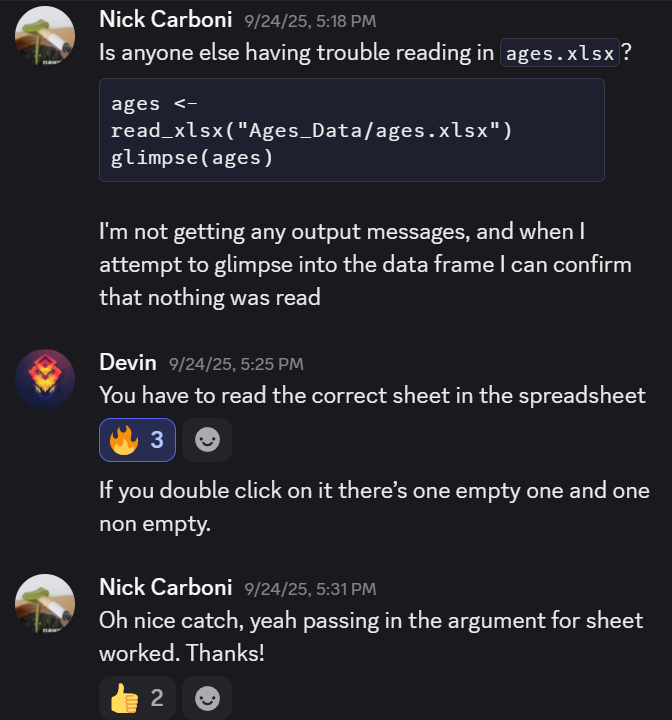

- Example #2: Pair Programming

> I grew as a collaborator through the pair programming activities by being more mindful of helping my partners learn, rather than jumping to the answer. There would be times when I was the typer, and my partner was struggling to remember which function to call. Rather than just telling them my approach, I learned to let them experiment and help nudge them in the right direction when they asked for help.

> In return, there were plenty of times where I was on the other side of this, and I appreciated being given time for trial and error where I felt like I could learn and make connections on my own.

> I also enjoyed how each pairing was a new dynamic. Everyone I worked with was great, and it was fun getting to see how everyone has different approaches with these pair programming activities.